# 統計学2

課題5の解答例

矢内 勇生

2019-05-15

# 問題

日本の成人女性の平均身長が、平均 160cm, 標準偏差 6cm の正規分布にしたがっていると仮定する。 このとき、標本サイズ ($n$) が 10, 50, 100のそれぞれの場合について、標本抽出を繰り返し、標本平均がどのように分布するか調べなさい。シミュレーションの繰り返し回数は1万回以上で自由に設定してよい。

1. それぞれの標本サイズで、標本平均の分布を示すヒストグラムを作りなさい。
2. それぞれの標本サイズで、標準平均の平均値を計算しなさい。
3. それぞれの標本サイズで、標準誤差を計算しなさい。
4. 最後に、今回の課題からどのようなことを学んだか、1段落程度で述べなさい。

# 準備

必要なパッケージを読み込む。

```r
library("tidyverse")
```

**Macユーザのみ**次のコードも実行する。

```r
theme_set(theme_gray(base_size = 10, base_family = "HiraginoSans-W3"))
```

# 解答例

## シミュレーション問題の設定

母集団（成人女性全体）では、平均身長が160cm、身長の標準偏差が 6cm であり、身長は正規分布に従っているので、以下のように母数を設定する。

```r
mu <- 160     # 母平均
sigma <- 6    # 母標準偏差
```

各シミュレーションの繰り返し回数を10万回に設定する。

```r
n_sims <- 10^5  # シミュレーションの繰り返し回数
```

## 標本サイズ ($n$) が10のとき

標本サイズ $n=10$ で、標本を抽出し、標本平均を計算することを10万回繰り返す。 まず、$n$ を設定する。

```r
n <- 10
```

forループを使ってシミュレーションを実行してみよう。

まず、結果保存用に、10万個の値を保存する容器（ベクトル）を用意する。要素は NA にしておく。

```r
sim_10 <- rep(NA, n_sims)
```

シミュレーションを実行する準備が整ったので、forループでシミュレーションを実行する。

```r
for (i in 1:n_sims) {
  h <- rnorm(n, mean = mu, sd = sigma)
  sim_10[i] <- mean(h)
}
```

結果をヒストグラムにしてみよう。

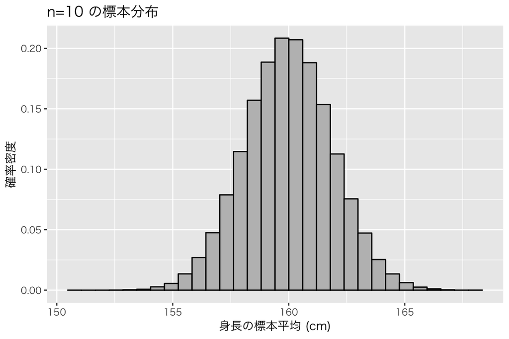

```r
df_sim <- tibble(sim_10)
hist_1 <- ggplot(df_sim, aes(x = sim_10, y = ..density..)) +
  geom_histogram(color = "black", fill = "gray") +
  labs(x = "身長の標本平均 (cm)", y = "確率密度",
       title = "n=10 の標本分布")
plot(hist_1)
```

このヒストグラムに、平均 160、標準偏差 6 の正規分布の確率密度曲線を重ね書きしてみよう。

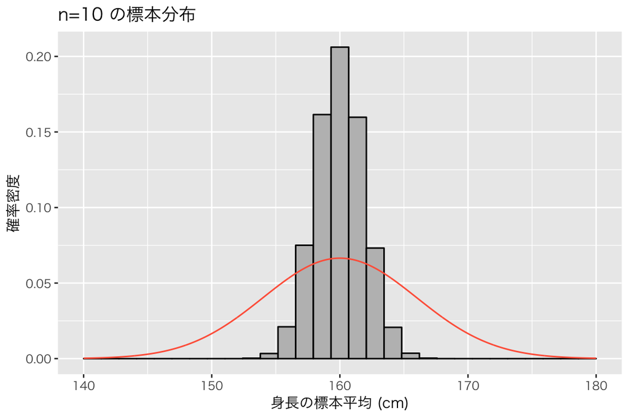

```r
df_normal <- tibble(x = seq(from = 140, to = 180, length.out = 1000))
df_normal$dens <- dnorm(df_normal$x, mean = 160, sd = 6)
hist_1b <- hist_1 +
  geom_line(data = df_normal, aes(x = x, y = dens), color = "tomato")
plot(hist_1b)
```

標本平均の平均値は、

```r
mean(sim_10)
```

```
## [1] 159.9897
```

であり、これは母平均とほぼ同じである。

標準誤差は、

```r
sd(sim_10)   # 標本平均の標準偏差 = 標準誤差
```

```
## [1] 1.890167
```

である。これは、理論的に期待される、

```r
sigma / sqrt(n)
```

```
## [1] 1.897367
```

とほぼ同じである。

## 標本サイズ ($n$) が50のとき

標本サイズ $n=50$ で、標本を抽出し、標本平均を計算することを10万回繰り返す。 まず、$n$ を設定する。

```r
n <- 50
```

forループを使ってシミュレーションを実行してみよう。

まず、結果保存用に、10万個の値を保存する容器（ベクトル）を用意する。要素は NA にしておく。

```r
sim_50 <- rep(NA, n_sims)
```

シミュレーションを実行する準備が整ったので、forループでシミュレーションを実行する。

```r
for (i in 1:n_sims) {
  h <- rnorm(n, mean = mu, sd = sigma)
  sim_50[i] <- mean(h)
}
```

結果をヒストグラムにしてみよう。

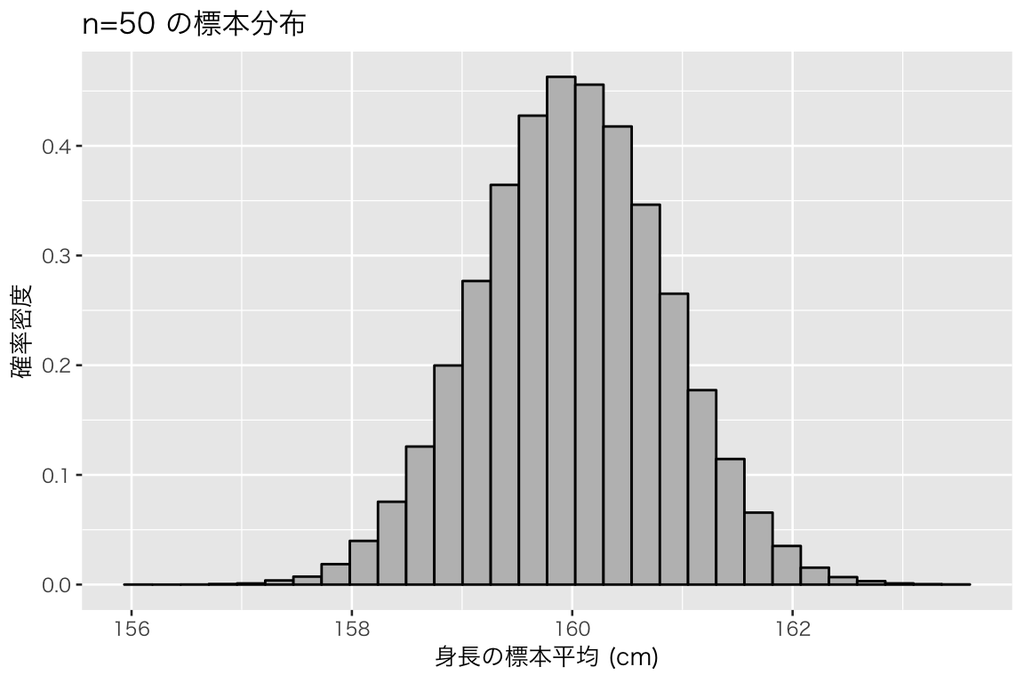

```r
df_sim$sim_50 <- sim_50
hist_2 <- ggplot(df_sim, aes(x = sim_50, y = ..density..)) +
  geom_histogram(color = "black", fill = "gray") +
  labs(x = "身長の標本平均 (cm)", y = "確率密度",
       title = "n=50 の標本分布")
plot(hist_2)
```

このヒストグラムに、平均 160、標準偏差 6 の正規分布の確率密度曲線を重ね書きしてみよう。

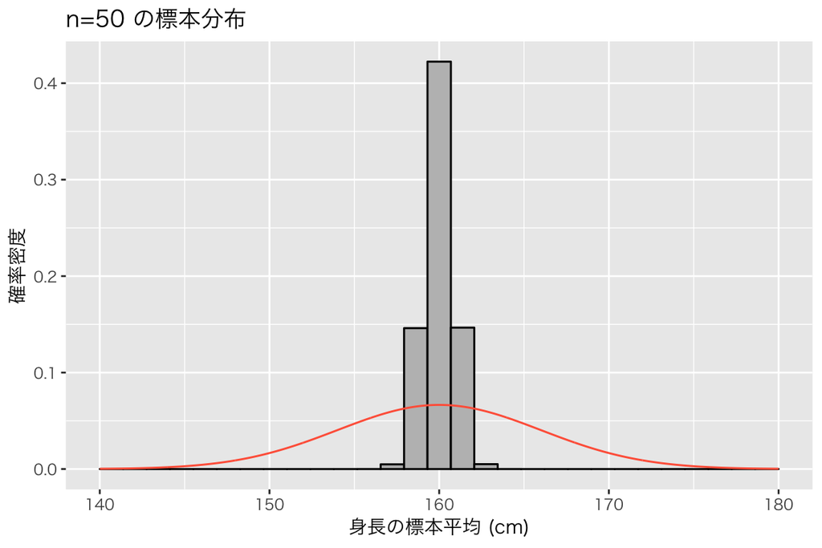

```r
hist_2b <- hist_2 +
  geom_line(data = df_normal, aes(x = x, y = dens), color = "tomato")
plot(hist_2b)
```

標本平均の平均値は、

```r
mean(sim_50)
```

```
## [1] 160.0006
```

であり、これは母平均とほぼ同じである。

標準誤差は、

```r
sd(sim_50)   # 標本平均の標準偏差 = 標準誤差
```

```
## [1] 0.8473082
```

である。これは、理論的に期待される、

```r
sigma / sqrt (n)
```

```
## [1] 0.8485281
```

とほぼ同じである。

## 標本サイズ ($n$) が100のとき

標本サイズ $n=100$ で、標本を抽出し、標本平均を計算することを10万回繰り返す。 まず、$n$ を設定する。

```r
n <- 100
```

forループを使ってシミュレーションを実行してみよう。

まず、結果保存用に、10万個の値を保存する容器（ベクトル）を用意する。要素は NA にしておく。

```r
sim_100 <- rep(NA, n_sims)
```

シミュレーションを実行する準備が整ったので、forループでシミュレーションを実行する。

```r
for (i in 1:n_sims) {
  h <- rnorm(n, mean = mu, sd = sigma)
  sim_100[i] <- mean(h)
}
```

結果をヒストグラムにしてみよう。

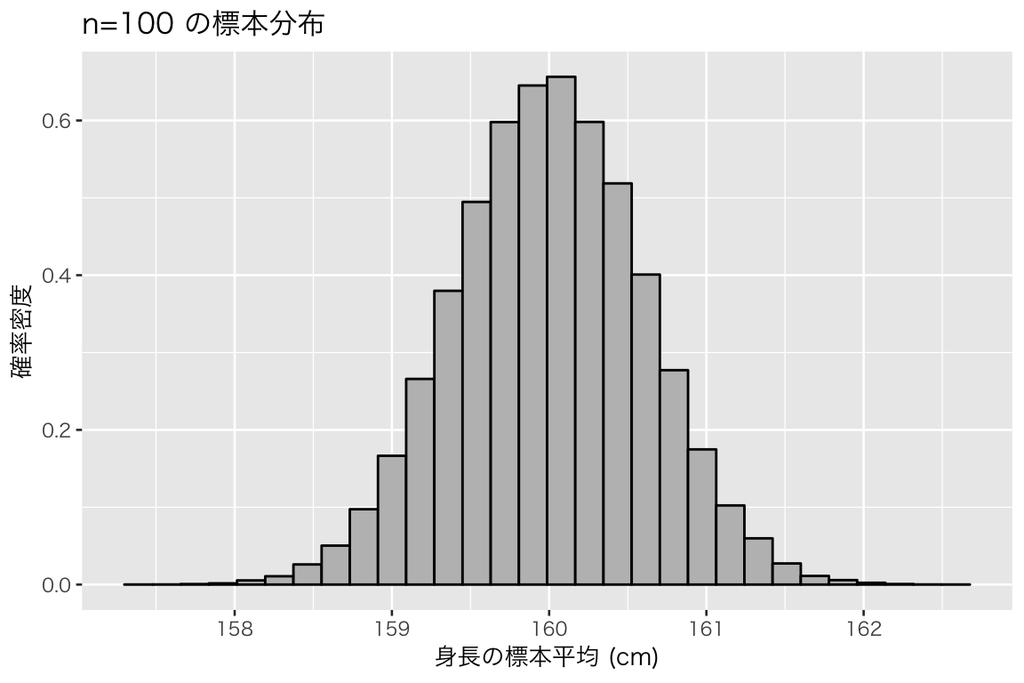

```r
df_sim$sim_100 <- sim_100
hist_3 <- ggplot(df_sim, aes(x = sim_100, y = ..density..)) +
  geom_histogram(color = "black", fill = "gray") +
  labs(x = "身長の標本平均 (cm)", y = "確率密度",
       title = "n=100 の標本分布")
plot(hist_3)
```

このヒストグラムに、平均 160、標準偏差 6 の正規分布の確率密度曲線を重ね書きしてみよう。

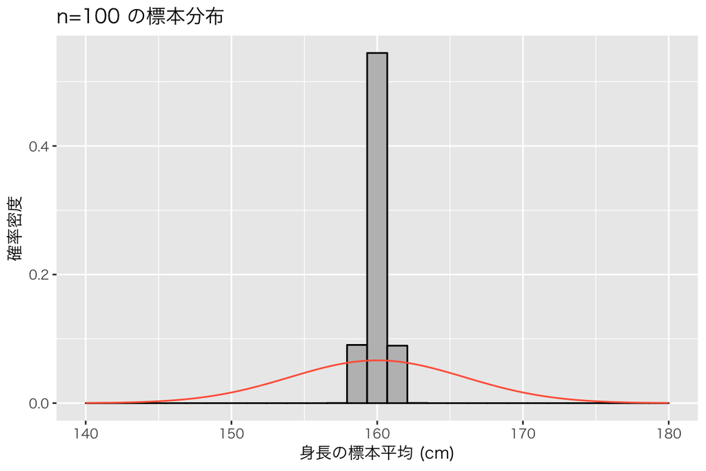

```r
hist_3b <- hist_3 +
  geom_line(data = df_normal, aes(x = x, y = dens), color = "tomato")
plot(hist_3b)
```

標本平均の平均値は、

```r
mean(sim_100)
```

```
## [1] 159.9987
```

であり、これは母平均とほぼ同じである。

標準誤差は、

```r
sd(sim_100)   # 標本平均の標準偏差 = 標準誤差
```

```
## [1] 0.5991592
```

である。これは、理論的に期待される、

```r
sigma / sqrt (n)
```

```
## [1] 0.6
```

とほぼ同じである。

# 別解：forループを使わずにシミュレーションを実行する (1)

まず、1回の標本抽出を行い、その標本の平均値を計算する関数を定義する。

```r
sample_height <- function(n, mean = 0, sd = 1) {
  ## 母集団から標本抽出を行い、標本平均を計算する関数
  ## 引数：n = 標本サイズ
  ##       mean = 母平均（既定値は0）
  ##       sd = 母標準偏差 (既定値は1)
  x <- rnorm(n, mean = mean, sd = sd)
  return(mean(x))
}
```

## n = 10 のとき

自分で定義した関数 `sample_height()` とシミュレーションを行うための関数である`replicate()` を使ってシミュレーションを行う。

```r
n_sims <- 10^5
sim_10_b <- replicate(n_sims, sample_height(n = 10, mean = mu, sd = sigma))
```

ヒストグラムの描き方は上と同じなので省略する。

**以下略**

# 別解：forループを使わずにシミュレーションを実行する (2)

一度に n $\times$ n_sims 個の値を抽出し、n個ごとにグループ分けしてグループごとの平均を求めればよい。

## $n=10$ の場合

まず、各観測値を行、グループ（つまり1つひとつの標本）を列にした、n行n_sims列の行列を作る。

```r
n <- 10
n_sims <- 10^5
sim_10_mat <- matrix(rnorm(10*10^5, mean = mu, sd = sigma),
                     nrow = n, ncol = n_sims)
```

次に、各列（各標本）の平均値を、`colMeans()` で求める。

```r
sim_10_c <- colMeans(sim_10_mat)
```

ヒストグラムの描き方は上と同じなので省略する。

**以下略**

これらのシミュレーションから、標本ごとのばらつきは、標本サイズ $n$ が大きくなるにつれて小さくなっていくことがわかる。つまり、標本サイズを大きくすれば、誤差を小さくできることがわかる。しかし、標本平均の平均は、標本サイズの大きさにかかわらず、つねに母平均に（ほぼ）一致する。つまり、標本平均は母平均の不偏推定量であることがわかる。

授業の内容に戻る